# Peer-graded Assignment: Course Project 2 - NOAA Storm Database Data Analysis

Oscar Mendoza

March, 2020

## Introduction

Storms and other severe weather events can cause both public health and economic problems for communities and municipalities. Many severe events can result in fatalities, injuries, and property damage, and preventing such outcomes to the extent possible is a key concern.

This project involves exploring the U.S. National Oceanic and Atmospheric Administration’s (NOAA) storm database. This database tracks characteristics of major storms and weather events in the United States, including when and where they occur, as well as estimates of any fatalities, injuries and property damage.

## Synopsis

Storm Data is being recorded in the US by NOAA since 1950. After a careful checking of the database, some processing was done in order to develop a workflow to identify the most harmful events, both on health and economics. Being guided by the original documentation, a new dataframe was created with more representative events, and using Pareto’s principle, the storm events were identified. In terms of health (casualties = injuries + fatalities), the most dangerous events were tornadoes. In terms of economics (crop damage + property damage), the most destructive events were floods and hurricanes.

## Data

The data for the assignment come in the form of a csv file compressed using a bzip2 algorithm. Further information can be found directly in the following links

- Nationa Weather Service Storm Data Documentation
- National Climatic Data Center Storm Events FAQ

The events in the database start in the year 1950 and end in November 2011. In the earlier years of the database there are generally fewer events recorded, most likely due to a lack of good records. More recent years should be considered more complete.

## Data Processing

The data provided is stored in a csv compressed file called **repdata_data_StormData.csv.bz2**

### Data Loading

```r
StormDataRaw <- read.table(file = "repdata_data_StormData.csv.bz2", header = TRUE, sep =",")
```

The dataframe has the following dimensions

```r
dim(StormDataRaw)
```

```
## [1] 902297     37
```

And the following structure

```r
str(StormDataRaw)
```

```
## 'data.frame':    902297 obs. of  37 variables:
##  $ STATE__   : num  1 1 1 1 1 1 1 1 1 1 ...
##  $ BGN_DATE  : Factor w/ 16335 levels "1/1/1966 0:00:00",..: 6523 6523 4242 11116 2224 2224 2260 383 3980 3980 ...
##  $ BGN_TIME  : Factor w/ 3608 levels "00:00:00 AM",..: 272 287 2705 1683 2584 3186 242 1683 3186 3186 ...
##  $ TIME_ZONE : Factor w/ 22 levels "ADT","AKS","AST",..: 7 7 7 7 7 7 7 7 7 7 ...
##  $ COUNTY    : num  97 3 57 89 43 77 9 123 125 57 ...
##  $ COUNTYNAME: Factor w/ 29601 levels "","5NM E OF MACKINAC BRIDGE TO PRESQUE ISLE LT MI",..: 13513 1873 4598 10592 4372 10094 1973 23873 24418 4598 ...
##  $ STATE     : Factor w/ 72 levels "AK","AL","AM",..: 2 2 2 2 2 2 2 2 2 2 ...
##  $ EVTYPE    : Factor w/ 985 levels "   HIGH SURF ADVISORY",..: 834 834 834 834 834 834 834 834 834 834 ...
##  $ BGN_RANGE : num  0 0 0 0 0 0 0 0 0 0 ...
##  $ BGN_AZI   : Factor w/ 35 levels "","  N"," NW",..: 1 1 1 1 1 1 1 1 1 1 ...
##  $ BGN_LOCATI: Factor w/ 54429 levels "","- 1 N Albion",..: 1 1 1 1 1 1 1 1 1 1 ...
##  $ END_DATE  : Factor w/ 6663 levels "","1/1/1993 0:00:00",..: 1 1 1 1 1 1 1 1 1 1 ...
##  $ END_TIME  : Factor w/ 3647 levels ""," 0900CST",..: 1 1 1 1 1 1 1 1 1 1 ...
##  $ COUNTY_END: num  0 0 0 0 0 0 0 0 0 0 ...
```

[output cut: 23 more lines]

### Data Manipulation and Subsetting

As it was seen in the structure of the file, several variables show some inconsistencies that must be adressed.

- BGN_DATE: Beginning Date of the Storm Event.
- EVTYPE: Storm Event type. Factor variable with 985 levels. (according to the Storm Data Documentation, There should be only 48 events).
- END_DATE: End Date of the Storm Event.
- PROPDMG: Property Damage done by the Storm Event.
- PROPDMGEXP: Property Damage Exponent/Value. The final damage in dollars will be computed based on this exponent.
- CROPDMG: Crop Damage done by the Storm Event.
- CROPDMGEXP: Crop Damage Exponent/Value. The final damage in dollars will be computed based on this exponent.

First, a new dataframe will be created so the data processing will be done in it.

```r
StormDataProcessed <- StormDataRaw[, c("STATE",
                                       "BGN_DATE",
                                       "EVTYPE",
                                       "END_DATE",
                                       "FATALITIES",
                                       "INJURIES",
                                       "PROPDMG",
                                       "PROPDMGEXP",
                                       "CROPDMG",
                                       "CROPDMGEXP",
                                       "REMARKS",
                                       "REFNUM")]
```

The dates for both *BGN_DATE* and *END_DATE* will be reprocessed

```r
StormDataProcessed$BGN_DATE <- as.Date(StormDataProcessed$BGN_DATE, format = "%m/%d/%Y")

StormDataProcessed$END_DATE <- as.Date(StormDataProcessed$END_DATE, format = "%m/%d/%Y")
```

Now, according to the documentation, data from 1996 and after is considered to be more completed. So, the first thing is to subset the events which happened after 1996 in **BGN_DATE**

```r
StormDataProcessed <- subset(x = StormDataProcessed, BGN_DATE >= "1996-01-01")
```

According to the str function, there are 985 factor levels on the **EVTYPE** variable. Now, according to the Data Documentation, there should be only 48 factor levels. The following workflow assures that there will be only the EVTYPES described in the documentation.

```r
#Firstly, take all the EVTYPE values to Upper, using the toupper() function
StormDataProcessed$EVTYPE <- toupper(StormDataProcessed$EVTYPE)

#The following piece of code creates a new column called EVENT
StormDataProcessed$EVENT <- NA

#And then, all the EVTYPES are organized in different EVENTS.

#WINTER WEATHER
StormDataProcessed$EVENT[grepl(pattern = "WINTRY MIX", x = StormDataProcessed$EVTYPE)] <- "WINTER WEATHER"
StormDataProcessed$EVENT[grepl(pattern = "WINTERY MIX", x = StormDataProcessed$EVTYPE)] <- "WINTER WEATHER"
StormDataProcessed$EVENT[grepl(pattern = "WINTER WEATHER/MIX", x = StormDataProcessed$EVTYPE)] <- "WINTER WEATHER"
StormDataProcessed$EVENT[grepl(pattern = "WINTER WEATHER MIX", x = StormDataProcessed$EVTYPE)] <- "WINTER WEATHER"
StormDataProcessed$EVENT[grepl(pattern = "WINTER WEATHER", x = StormDataProcessed$EVTYPE)] <- "WINTER WEATHER"
StormDataProcessed$EVENT[grepl(pattern = "WINTER MIX", x = StormDataProcessed$EVTYPE)] <- "WINTER WEATHER"
StormDataProcessed$EVENT[grepl(pattern = "UNUSUALLY LATE SNOW", x = StormDataProcessed$EVTYPE)] <- "WINTER WEATHER"
StormDataProcessed$EVENT[grepl(pattern = "UNUSUALLY COLD", x = StormDataProcessed$EVTYPE)] <- "WINTER WEATHER"
StormDataProcessed$EVENT[grepl(pattern = "LIGHT SNOWFALL", x = StormDataProcessed$EVTYPE)] <- "WINTER WEATHER"
StormDataProcessed$EVENT[grepl(pattern = "LIGHT SNOW/FREEZING PRECIP", x = StormDataProcessed$EVTYPE)] <- "WINTER WEATHER"
StormDataProcessed$EVENT[grepl(pattern = "LIGHT SNOW/FLURRIES", x = StormDataProcessed$EVTYPE)] <- "WINTER WEATHER"
StormDataProcessed$EVENT[grepl(pattern = "LIGHT SNOW", x = StormDataProcessed$EVTYPE)] <- "WINTER WEATHER"
StormDataProcessed$EVENT[grepl(pattern = "LIGHT FREEZING RAIN", x = StormDataProcessed$EVTYPE)] <- "WINTER WEATHER"
StormDataProcessed$EVENT[grepl(pattern = "LATE SNOW", x = StormDataProcessed$EVTYPE)] <- "WINTER WEATHER"
StormDataProcessed$EVENT[grepl(pattern = "LATE SEASON SNOWFALL", x = StormDataProcessed$EVTYPE)] <- "WINTER WEATHER"
StormDataProcessed$EVENT[grepl(pattern = "LATE SEASON SNOW", x = StormDataProcessed$EVTYPE)] <- "WINTER WEATHER"
StormDataProcessed$EVENT[grepl(pattern = "LATE-SEASON SNOWFALL", x = StormDataProcessed$EVTYPE)] <- "WINTER WEATHER"
StormDataProcessed$EVENT[grepl(pattern = "FIRST SNOW", x = StormDataProcessed$EVTYPE)] <- "WINTER WEATHER"
StormDataProcessed$EVENT[grepl(pattern = "EARLY SNOWFALL", x = StormDataProcessed$EVTYPE)] <- "WINTER WEATHER"
StormDataProcessed$EVENT[grepl(pattern = "COOL SPELL", x = StormDataProcessed$EVTYPE)] <- "WINTER WEATHER"
StormDataProcessed$EVENT[grepl(pattern = "BLOWING SNOW", x = StormDataProcessed$EVTYPE)] <- "WINTER WEATHER"
StormDataProcessed$EVENT[grepl(pattern = "WINTER STORM", x = StormDataProcessed$EVTYPE)] <- "WINTER WEATHER"


#STRONG WIND
StormDataProcessed$EVENT[grepl(pattern = "WND", x = StormDataProcessed$EVTYPE)] <- "STRONG WIND"
StormDataProcessed$EVENT[grepl(pattern = "WIND GUSTS", x = StormDataProcessed$EVTYPE)] <- "STRONG WIND"
StormDataProcessed$EVENT[grepl(pattern = "WINDS", x = StormDataProcessed$EVTYPE)] <- "STRONG WIND"
StormDataProcessed$EVENT[grepl(pattern = "WIND DAMAGE", x = StormDataProcessed$EVTYPE)] <- "STRONG WIND"
StormDataProcessed$EVENT[grepl(pattern = "WIND CHILL", x = StormDataProcessed$EVTYPE)] <- "STRONG WIND"
StormDataProcessed$EVENT[grepl(pattern = "WIND AND WAVE", x = StormDataProcessed$EVTYPE)] <- "STRONG WIND"
StormDataProcessed$EVENT[grepl(pattern = "WIND ADVISORY", x = StormDataProcessed$EVTYPE)] <- "STRONG WIND"
StormDataProcessed$EVENT[grepl(pattern = "WIND", x = StormDataProcessed$EVTYPE)] <- "STRONG WIND"
StormDataProcessed$EVENT[grepl(pattern = "WHIRLWIND", x = StormDataProcessed$EVTYPE)] <- "STRONG WIND"
StormDataProcessed$EVENT[grepl(pattern = "WAKE LOW WIND", x = StormDataProcessed$EVTYPE)] <- "STRONG WIND"
StormDataProcessed$EVENT[grepl(pattern = "BLOW-OUT TIDES", x = StormDataProcessed$EVTYPE)] <- "STRONG WIND"
StormDataProcessed$EVENT[grepl(pattern = "BLOW-OUT TIDE", x = StormDataProcessed$EVTYPE)] <- "STRONG WIND"

#WILDFIRE
StormDataProcessed$EVENT[grepl(pattern = "WILDFIRE", x = StormDataProcessed$EVTYPE)] <- "WILDFIRE"
StormDataProcessed$EVENT[grepl(pattern = "WILD/FOREST FIRE", x = StormDataProcessed$EVTYPE)] <- "WILDFIRE"
StormDataProcessed$EVENT[grepl(pattern = "SMOKE", x = StormDataProcessed$EVTYPE)] <- "WILDFIRE"
StormDataProcessed$EVENT[grepl(pattern = "DENSE SMOKE", x = StormDataProcessed$EVTYPE)] <- "WILDFIRE"
StormDataProcessed$EVENT[grepl(pattern = "BRUSH FIRE", x = StormDataProcessed$EVTYPE)] <- "WILDFIRE"

#HEAVY RAIN
StormDataProcessed$EVENT[grepl(pattern = "WET YEAR", x = StormDataProcessed$EVTYPE)] <- "HEAVY RAIN"
StormDataProcessed$EVENT[grepl(pattern = "WET MONTH", x = StormDataProcessed$EVTYPE)] <- "HEAVY RAIN"
StormDataProcessed$EVENT[grepl(pattern = "WET MICROBURST", x = StormDataProcessed$EVTYPE)] <- "HEAVY RAIN"
StormDataProcessed$EVENT[grepl(pattern = "WET MICOBURST", x = StormDataProcessed$EVTYPE)] <- "HEAVY RAIN"
StormDataProcessed$EVENT[grepl(pattern = "UNSEASONAL RAIN", x = StormDataProcessed$EVTYPE)] <- "HEAVY RAIN"
StormDataProcessed$EVENT[grepl(pattern = "UNSEASONABLY WET", x = StormDataProcessed$EVTYPE)] <- "HEAVY RAIN"
StormDataProcessed$EVENT[grepl(pattern = "TORRENTIAL RAINFALL", x = StormDataProcessed$EVTYPE)] <- "HEAVY RAIN"
StormDataProcessed$EVENT[grepl(pattern = "RECORD RAINFALL", x = StormDataProcessed$EVTYPE)] <- "HEAVY RAIN"
StormDataProcessed$EVENT[grepl(pattern = "RECORD PRECIPITATION", x = StormDataProcessed$EVTYPE)] <- "HEAVY RAIN"
StormDataProcessed$EVENT[grepl(pattern = "RAIN DAMAGE", x = StormDataProcessed$EVTYPE)] <- "HEAVY RAIN"
StormDataProcessed$EVENT[grepl(pattern = "RAIN (HEAVY)", x = StormDataProcessed$EVTYPE)] <- "HEAVY RAIN"
StormDataProcessed$EVENT[grepl(pattern = "RAIN", x = StormDataProcessed$EVTYPE)] <- "HEAVY RAIN"
StormDataProcessed$EVENT[grepl(pattern = "PROLONGED RAIN", x = StormDataProcessed$EVTYPE)] <- "HEAVY RAIN"
StormDataProcessed$EVENT[grepl(pattern = "MONTHLY RAINFALL", x = StormDataProcessed$EVTYPE)] <- "HEAVY RAIN"
StormDataProcessed$EVENT[grepl(pattern = "MONTHLY PRECIPITATION", x = StormDataProcessed$EVTYPE)] <- "HEAVY RAIN"
StormDataProcessed$EVENT[grepl(pattern = "MICROBURST", x = StormDataProcessed$EVTYPE)] <- "HEAVY RAIN"
StormDataProcessed$EVENT[grepl(pattern = "LOCALLY HEAVY RAIN", x = StormDataProcessed$EVTYPE)] <- "HEAVY RAIN"
StormDataProcessed$EVENT[grepl(pattern = "HEAVY RAINFALL", x = StormDataProcessed$EVTYPE)] <- "HEAVY RAIN"
StormDataProcessed$EVENT[grepl(pattern = "HEAVY RAIN/WIND", x = StormDataProcessed$EVTYPE)] <- "HEAVY RAIN"
StormDataProcessed$EVENT[grepl(pattern = "HEAVY RAIN/HIGH SURF", x = StormDataProcessed$EVTYPE)] <- "HEAVY RAIN"
StormDataProcessed$EVENT[grepl(pattern = "HEAVY RAIN EFFECTS", x = StormDataProcessed$EVTYPE)] <- "HEAVY RAIN"
StormDataProcessed$EVENT[grepl(pattern = "HEAVY RAIN AND WIND", x = StormDataProcessed$EVTYPE)] <- "HEAVY RAIN"
StormDataProcessed$EVENT[grepl(pattern = "HEAVY RAIN", x = StormDataProcessed$EVTYPE)] <- "HEAVY RAIN"
StormDataProcessed$EVENT[grepl(pattern = "HEAVY PRECIPITATION", x = StormDataProcessed$EVTYPE)] <- "HEAVY RAIN"
StormDataProcessed$EVENT[grepl(pattern = "EXCESSIVE RAINFALL", x = StormDataProcessed$EVTYPE)] <- "HEAVY RAIN"
StormDataProcessed$EVENT[grepl(pattern = "EXCESSIVE RAIN", x = StormDataProcessed$EVTYPE)] <- "HEAVY RAIN"
StormDataProcessed$EVENT[grepl(pattern = "EARLY RAIN", x = StormDataProcessed$EVTYPE)] <- "HEAVY RAIN"
StormDataProcessed$EVENT[grepl(pattern = "DRY MICROBURST", x = StormDataProcessed$EVTYPE)] <- "HEAVY RAIN"
StormDataProcessed$EVENT[grepl(pattern = "DOWNBURST", x = StormDataProcessed$EVTYPE)] <- "HEAVY RAIN"
```

```r
#WATERSPOUT
StormDataProcessed$EVENT[grepl(pattern = "WATERSPOUT", x = StormDataProcessed$EVTYPE)] <- "WATERSPOUT"
StormDataProcessed$EVENT[grepl(pattern = "WATERSPOUTS", x = StormDataProcessed$EVTYPE)] <- "WATERSPOUT"

#HEAT
StormDataProcessed$EVENT[grepl(pattern = "WARM WEATHER", x = StormDataProcessed$EVTYPE)] <- "HEAT"
StormDataProcessed$EVENT[grepl(pattern = "VERY WARM", x = StormDataProcessed$EVTYPE)] <- "HEAT"
StormDataProcessed$EVENT[grepl(pattern = "UNUSUALLY WARM", x = StormDataProcessed$EVTYPE)] <- "HEAT"
StormDataProcessed$EVENT[grepl(pattern = "UNUSUAL/RECORD WARMTH", x = StormDataProcessed$EVTYPE)] <- "HEAT"
StormDataProcessed$EVENT[grepl(pattern = "UNUSUAL WARMTH", x = StormDataProcessed$EVTYPE)] <- "HEAT"
StormDataProcessed$EVENT[grepl(pattern = "UNSEASONABLY WARM/WET", x = StormDataProcessed$EVTYPE)] <- "HEAT"
StormDataProcessed$EVENT[grepl(pattern = "UNSEASONABLY WARM YEAR", x = StormDataProcessed$EVTYPE)] <- "HEAT"
StormDataProcessed$EVENT[grepl(pattern = "UNSEASONABLY WARM & WET", x = StormDataProcessed$EVTYPE)] <- "HEAT"
StormDataProcessed$EVENT[grepl(pattern = "UNSEASONABLY WARM", x = StormDataProcessed$EVTYPE)] <- "HEAT"
StormDataProcessed$EVENT[grepl(pattern = "UNSEASONABLY HOT", x = StormDataProcessed$EVTYPE)] <- "HEAT"
StormDataProcessed$EVENT[grepl(pattern = "TEMPERATURE RECORD", x = StormDataProcessed$EVTYPE)] <- "HEAT"
StormDataProcessed$EVENT[grepl(pattern = "RECORD WARMTH", x = StormDataProcessed$EVTYPE)] <- "HEAT"
StormDataProcessed$EVENT[grepl(pattern = "RECORD WARM TEMPS.", x = StormDataProcessed$EVTYPE)] <- "HEAT"
StormDataProcessed$EVENT[grepl(pattern = "RECORD WARM", x = StormDataProcessed$EVTYPE)] <- "HEAT"
StormDataProcessed$EVENT[grepl(pattern = "RECORD TEMPERATURES", x = StormDataProcessed$EVTYPE)] <- "HEAT"
StormDataProcessed$EVENT[grepl(pattern = "RECORD TEMPERATURE", x = StormDataProcessed$EVTYPE)] <- "HEAT"
StormDataProcessed$EVENT[grepl(pattern = "RECORD HIGH", x = StormDataProcessed$EVTYPE)] <- "HEAT"
StormDataProcessed$EVENT[grepl(pattern = "RECORD HEAT", x = StormDataProcessed$EVTYPE)] <- "HEAT"
StormDataProcessed$EVENT[grepl(pattern = "PROLONG WARMTH", x = StormDataProcessed$EVTYPE)] <- "HEAT"
StormDataProcessed$EVENT[grepl(pattern = "HYPERTHERMIA/EXPOSURE", x = StormDataProcessed$EVTYPE)] <- "HEAT"
StormDataProcessed$EVENT[grepl(pattern = "HOT WEATHER", x = StormDataProcessed$EVTYPE)] <- "HEAT"
StormDataProcessed$EVENT[grepl(pattern = "HOT SPELL", x = StormDataProcessed$EVTYPE)] <- "HEAT"
StormDataProcessed$EVENT[grepl(pattern = "HOT AND DRY", x = StormDataProcessed$EVTYPE)] <- "HEAT"
StormDataProcessed$EVENT[grepl(pattern = "HEATBURST", x = StormDataProcessed$EVTYPE)] <- "HEAT"
StormDataProcessed$EVENT[grepl(pattern = "HEAT WAVE", x = StormDataProcessed$EVTYPE)] <- "HEAT"
StormDataProcessed$EVENT[grepl(pattern = "HEAT", x = StormDataProcessed$EVTYPE)] <- "HEAT"
StormDataProcessed$EVENT[grepl(pattern = "EXCESSIVE HEAT", x = StormDataProcessed$EVTYPE)] <- "HEAT"
StormDataProcessed$EVENT[grepl(pattern = "ABNORMAL WARMTH", x = StormDataProcessed$EVTYPE)] <- "HEAT"


#TORNADO
StormDataProcessed$EVENT[grepl(pattern = "WALL CLOUD", x = StormDataProcessed$EVTYPE)] <- "TORNADO"
StormDataProcessed$EVENT[grepl(pattern = "TORNADO DEBRIS", x = StormDataProcessed$EVTYPE)] <- "TORNADO"
StormDataProcessed$EVENT[grepl(pattern = "TORNADO", x = StormDataProcessed$EVTYPE)] <- "TORNADO"
StormDataProcessed$EVENT[grepl(pattern = "LANDSPOUT", x = StormDataProcessed$EVTYPE)] <- "TORNADO"

#FUNNEL CLOUD
StormDataProcessed$EVENT[grepl(pattern = "FUNNEL CLOUDS", x = StormDataProcessed$EVTYPE)] <- "FUNNEL CLOUD"
StormDataProcessed$EVENT[grepl(pattern = "FUNNEL CLOUD", x = StormDataProcessed$EVTYPE)] <- "FUNNEL CLOUD"

#VOLCANIC ASH
StormDataProcessed$EVENT[grepl(pattern = "VOLCANIC ERUPTION", x = StormDataProcessed$EVTYPE)] <- "VOLCANIC ASH"
StormDataProcessed$EVENT[grepl(pattern = "VOLCANIC ASHFALL", x = StormDataProcessed$EVTYPE)] <- "VOLCANIC ASH"
StormDataProcessed$EVENT[grepl(pattern = "VOLCANIC ASH PLUME", x = StormDataProcessed$EVTYPE)] <- "VOLCANIC ASH"
StormDataProcessed$EVENT[grepl(pattern = "VOLCANIC ASH", x = StormDataProcessed$EVTYPE)] <- "VOLCANIC ASH"
StormDataProcessed$EVENT[grepl(pattern = "VOG", x = StormDataProcessed$EVTYPE)] <- "VOLCANIC ASH"

#DROUGHT
StormDataProcessed$EVENT[grepl(pattern = "VERY DRY", x = StormDataProcessed$EVTYPE)] <- "DROUGHT"
StormDataProcessed$EVENT[grepl(pattern = "UNSEASONABLY WARM AND DRY", x = StormDataProcessed$EVTYPE)] <- "DROUGHT"
StormDataProcessed$EVENT[grepl(pattern = "UNSEASONABLY DRY", x = StormDataProcessed$EVTYPE)] <- "DROUGHT"
StormDataProcessed$EVENT[grepl(pattern = "RECORD LOW RAINFALL", x = StormDataProcessed$EVTYPE)] <- "DROUGHT"
StormDataProcessed$EVENT[grepl(pattern = "RECORD DRYNESS", x = StormDataProcessed$EVTYPE)] <- "DROUGHT"
StormDataProcessed$EVENT[grepl(pattern = "RECORD DRY MONTH", x = StormDataProcessed$EVTYPE)] <- "DROUGHT"
StormDataProcessed$EVENT[grepl(pattern = "MILD AND DRY PATTERN", x = StormDataProcessed$EVTYPE)] <- "DROUGHT"
StormDataProcessed$EVENT[grepl(pattern = "EXCESSIVELY DRY", x = StormDataProcessed$EVTYPE)] <- "DROUGHT"
StormDataProcessed$EVENT[grepl(pattern = "EXCESSIVE HEAT/DROUGHT", x = StormDataProcessed$EVTYPE)] <- "DROUGHT"
StormDataProcessed$EVENT[grepl(pattern = "DRYNESS", x = StormDataProcessed$EVTYPE)] <- "DROUGHT"
StormDataProcessed$EVENT[grepl(pattern = "DRY WEATHER", x = StormDataProcessed$EVTYPE)] <- "DROUGHT"
StormDataProcessed$EVENT[grepl(pattern = "DRY SPELL", x = StormDataProcessed$EVTYPE)] <- "DROUGHT"
StormDataProcessed$EVENT[grepl(pattern = "DRY CONDITIONS", x = StormDataProcessed$EVTYPE)] <- "DROUGHT"
StormDataProcessed$EVENT[grepl(pattern = "DRY", x = StormDataProcessed$EVTYPE)] <- "DROUGHT"
StormDataProcessed$EVENT[grepl(pattern = "DROUGHT", x = StormDataProcessed$EVTYPE)] <- "DROUGHT"
StormDataProcessed$EVENT[grepl(pattern = "DRIEST MONTH", x = StormDataProcessed$EVTYPE)] <- "DROUGHT"
StormDataProcessed$EVENT[grepl(pattern = "ABNORMALLY DRY", x = StormDataProcessed$EVTYPE)] <- "DROUGHT"
```

```r
#FLOOD
StormDataProcessed$EVENT[grepl(pattern = "URBAN/STREET FLOODING", x = StormDataProcessed$EVTYPE)] <- "FLOOD"
StormDataProcessed$EVENT[grepl(pattern = "URBAN/SML STREAM FLDG", x = StormDataProcessed$EVTYPE)] <- "FLOOD"
StormDataProcessed$EVENT[grepl(pattern = "URBAN/SML STREAM FLD", x = StormDataProcessed$EVTYPE)] <- "FLOOD"
StormDataProcessed$EVENT[grepl(pattern = "URBAN/SML STRM FLD", x = StormDataProcessed$EVTYPE)] <- "FLOOD"
StormDataProcessed$EVENT[grepl(pattern = "URBAN FLOODING", x = StormDataProcessed$EVTYPE)] <- "FLOOD"
StormDataProcessed$EVENT[grepl(pattern = "URBAN FLOOD", x = StormDataProcessed$EVTYPE)] <- "FLOOD"
StormDataProcessed$EVENT[grepl(pattern = "TIDAL FLOODING", x = StormDataProcessed$EVTYPE)] <- "FLOOD"
StormDataProcessed$EVENT[grepl(pattern = "STREET FLOODING", x = StormDataProcessed$EVTYPE)] <- "FLOOD"
StormDataProcessed$EVENT[grepl(pattern = "SNOWMELT FLOODING", x = StormDataProcessed$EVTYPE)] <- "FLOOD"
StormDataProcessed$EVENT[grepl(pattern = "SML STREAM FLD", x = StormDataProcessed$EVTYPE)] <- "FLOOD"
StormDataProcessed$EVENT[grepl(pattern = "RIVER FLOODING", x = StormDataProcessed$EVTYPE)] <- "FLOOD"
StormDataProcessed$EVENT[grepl(pattern = "RIVER FLOOD", x = StormDataProcessed$EVTYPE)] <- "FLOOD"
StormDataProcessed$EVENT[grepl(pattern = "MINOR FLOODING", x = StormDataProcessed$EVTYPE)] <- "FLOOD"
StormDataProcessed$EVENT[grepl(pattern = "FLOOD/STRONG WIND", x = StormDataProcessed$EVTYPE)] <- "FLOOD"
StormDataProcessed$EVENT[grepl(pattern = "FLOOD", x = StormDataProcessed$EVTYPE)] <- "FLOOD"
StormDataProcessed$EVENT[grepl(pattern = "EROSION/CSTL FLOOD", x = StormDataProcessed$EVTYPE)] <- "FLOOD"
StormDataProcessed$EVENT[grepl(pattern = "EROSION/CSTL FLOOD", x = StormDataProcessed$EVTYPE)] <- "FLOOD"
StormDataProcessed$EVENT[grepl(pattern = "URBAN/SMALL STRM FLDG", x = StormDataProcessed$EVTYPE)] <- "FLOOD"



#COLD/WIND CHILL
StormDataProcessed$EVENT[grepl(pattern = "UNSEASONAL LOW TEMP", x = StormDataProcessed$EVTYPE)] <- "COLD/WIND CHILL"
StormDataProcessed$EVENT[grepl(pattern = "UNSEASONABLY COOL & WET", x = StormDataProcessed$EVTYPE)] <- "COLD/WIND CHILL"
StormDataProcessed$EVENT[grepl(pattern = "UNSEASONABLY COOL", x = StormDataProcessed$EVTYPE)] <- "COLD/WIND CHILL"
StormDataProcessed$EVENT[grepl(pattern = "UNSEASONABLY COLD", x = StormDataProcessed$EVTYPE)] <- "COLD/WIND CHILL"
StormDataProcessed$EVENT[grepl(pattern = "UNSEASONABLE COLD", x = StormDataProcessed$EVTYPE)] <- "COLD/WIND CHILL"
StormDataProcessed$EVENT[grepl(pattern = "THUNDERSNOW SHOWER", x = StormDataProcessed$EVTYPE)] <- "COLD/WIND CHILL"
StormDataProcessed$EVENT[grepl(pattern = "RECORD COOL", x = StormDataProcessed$EVTYPE)] <- "COLD/WIND CHILL"
StormDataProcessed$EVENT[grepl(pattern = "RECORD COLD", x = StormDataProcessed$EVTYPE)] <- "COLD/WIND CHILL"
StormDataProcessed$EVENT[grepl(pattern = "RECORD  COLD", x = StormDataProcessed$EVTYPE)] <- "COLD/WIND CHILL"
StormDataProcessed$EVENT[grepl(pattern = "PROLONG COLD", x = StormDataProcessed$EVTYPE)] <- "COLD/WIND CHILL"
StormDataProcessed$EVENT[grepl(pattern = "MONTHLY TEMPERATURE", x = StormDataProcessed$EVTYPE)] <- "COLD/WIND CHILL"
StormDataProcessed$EVENT[grepl(pattern = "COLD/WIND CHILL", x = StormDataProcessed$EVTYPE)] <- "COLD/WIND CHILL"
StormDataProcessed$EVENT[grepl(pattern = "COLD WIND CHILL TEMPERATURES", x = StormDataProcessed$EVTYPE)] <- "COLD/WIND CHILL"
StormDataProcessed$EVENT[grepl(pattern = "COLD WEATHER", x = StormDataProcessed$EVTYPE)] <- "COLD/WIND CHILL"
StormDataProcessed$EVENT[grepl(pattern = "COLD TEMPERATURES", x = StormDataProcessed$EVTYPE)] <- "COLD/WIND CHILL"
StormDataProcessed$EVENT[grepl(pattern = "COLD TEMPERATURE", x = StormDataProcessed$EVTYPE)] <- "COLD/WIND CHILL"
StormDataProcessed$EVENT[grepl(pattern = "COLD AND SNOW", x = StormDataProcessed$EVTYPE)] <- "COLD/WIND CHILL"
StormDataProcessed$EVENT[grepl(pattern = "COLD", x = StormDataProcessed$EVTYPE)] <- "COLD/WIND CHILL"

#HURRICANE (TYPHOON)
StormDataProcessed$EVENT[grepl(pattern = "TYPHOON", x = StormDataProcessed$EVTYPE)] <- "HURRICANE (TYPHOON)"
StormDataProcessed$EVENT[grepl(pattern = "HURRICANE/TYPHOON", x = StormDataProcessed$EVTYPE)] <- "HURRICANE (TYPHOON)"
StormDataProcessed$EVENT[grepl(pattern = "HURRICANE EDOUARD", x = StormDataProcessed$EVTYPE)] <- "HURRICANE (TYPHOON)"
StormDataProcessed$EVENT[grepl(pattern = "HURRICANE", x = StormDataProcessed$EVTYPE)] <- "HURRICANE (TYPHOON)"


#TSUNAMI
StormDataProcessed$EVENT[grepl(pattern = "TSUNAMI", x = StormDataProcessed$EVTYPE)] <- "TSUNAMI"

#THUNDERSTORM WIND
StormDataProcessed$EVENT[grepl(pattern = "TSTM WND", x = StormDataProcessed$EVTYPE)] <- "THUNDERSTORM WIND"
StormDataProcessed$EVENT[grepl(pattern = "TSTM WINDS", x = StormDataProcessed$EVTYPE)] <- "THUNDERSTORM WIND"
StormDataProcessed$EVENT[grepl(pattern = "TSTM WIND/HAIL", x = StormDataProcessed$EVTYPE)] <- "THUNDERSTORM WIND"
StormDataProcessed$EVENT[grepl(pattern = "TSTM WIND G45", x = StormDataProcessed$EVTYPE)] <- "THUNDERSTORM WIND"
StormDataProcessed$EVENT[grepl(pattern = "TSTM WIND AND LIGHTING", x = StormDataProcessed$EVTYPE)] <- "THUNDERSTORM WIND"
StormDataProcessed$EVENT[grepl(pattern = "TSTM WIND 45", x = StormDataProcessed$EVTYPE)] <- "THUNDERSTORM WIND"
StormDataProcessed$EVENT[grepl(pattern = "TSTM WIND 40", x = StormDataProcessed$EVTYPE)] <- "THUNDERSTORM WIND"
StormDataProcessed$EVENT[grepl(pattern = "TSTM WIND (G45)", x = StormDataProcessed$EVTYPE)] <- "THUNDERSTORM WIND"
StormDataProcessed$EVENT[grepl(pattern = "TSTM WIND (G40)", x = StormDataProcessed$EVTYPE)] <- "THUNDERSTORM WIND"
StormDataProcessed$EVENT[grepl(pattern = "TSTM WIND (G35)", x = StormDataProcessed$EVTYPE)] <- "THUNDERSTORM WIND"
StormDataProcessed$EVENT[grepl(pattern = "TSTM WIND (G41)", x = StormDataProcessed$EVTYPE)] <- "THUNDERSTORM WIND"
StormDataProcessed$EVENT[grepl(pattern = "TSTM WIND  (G45)", x = StormDataProcessed$EVTYPE)] <- "THUNDERSTORM WIND"
StormDataProcessed$EVENT[grepl(pattern = "TSTM WIND", x = StormDataProcessed$EVTYPE)] <- "THUNDERSTORM WIND"
StormDataProcessed$EVENT[grepl(pattern = "TSTM HEAVY RAIN", x = StormDataProcessed$EVTYPE)] <- "THUNDERSTORM WIND"
StormDataProcessed$EVENT[grepl(pattern = "TSTM", x = StormDataProcessed$EVTYPE)] <- "THUNDERSTORM WIND"
StormDataProcessed$EVENT[grepl(pattern = "THUNDERSTORMS", x = StormDataProcessed$EVTYPE)] <- "THUNDERSTORM WIND"
StormDataProcessed$EVENT[grepl(pattern = "THUNDERSTORM WIND (G40)", x = StormDataProcessed$EVTYPE)] <- "THUNDERSTORM WIND"
StormDataProcessed$EVENT[grepl(pattern = "THUNDERSTORM WIND", x = StormDataProcessed$EVTYPE)] <- "THUNDERSTORM WIND"
StormDataProcessed$EVENT[grepl(pattern = "THUNDERSTORM", x = StormDataProcessed$EVTYPE)] <- "THUNDERSTORM WIND"
StormDataProcessed$EVENT[grepl(pattern = "SEVERE THUNDERSTORMS", x = StormDataProcessed$EVTYPE)] <- "THUNDERSTORM WIND"
StormDataProcessed$EVENT[grepl(pattern = "SEVERE THUNDERSTORM", x = StormDataProcessed$EVTYPE)] <- "THUNDERSTORM WIND"
StormDataProcessed$EVENT[grepl(pattern = "NON TSTM WIND", x = StormDataProcessed$EVTYPE)] <- "THUNDERSTORM WIND"
StormDataProcessed$EVENT[grepl(pattern = "NON-TSTM WIND", x = StormDataProcessed$EVTYPE)] <- "THUNDERSTORM WIND"
StormDataProcessed$EVENT[grepl(pattern = "NON-SEVERE WIND DAMAGE", x = StormDataProcessed$EVTYPE)] <- "THUNDERSTORM WIND"
StormDataProcessed$EVENT[grepl(pattern = "NO SEVERE WEATHER", x = StormDataProcessed$EVTYPE)] <- "THUNDERSTORM WIND"
StormDataProcessed$EVENT[grepl(pattern = "METRO STORM, MAY 26", x = StormDataProcessed$EVTYPE)] <- "THUNDERSTORM WIND"
StormDataProcessed$EVENT[grepl(pattern = "GUSTY THUNDERSTORM WINDS", x = StormDataProcessed$EVTYPE)] <- "THUNDERSTORM WIND"
StormDataProcessed$EVENT[grepl(pattern = "GUSTY THUNDERSTORM WIND", x = StormDataProcessed$EVTYPE)] <- "THUNDERSTORM WIND"
```

```r
#TROPICAL STORM
StormDataProcessed$EVENT[grepl(pattern = "TROPICAL STORM", x = StormDataProcessed$EVTYPE)] <- "TROPICAL STORM"
StormDataProcessed$EVENT[grepl(pattern = "REMNANTS OF FLOYD", x = StormDataProcessed$EVTYPE)] <- "TROPICAL STORM"


#TROPICAL DEPRESSION
StormDataProcessed$EVENT[grepl(pattern = "TROPICAL DEPRESSION", x = StormDataProcessed$EVTYPE)] <- "TROPICAL DEPRESSION"

#TEMPERATURE RECORD
StormDataProcessed$EVENT[grepl(pattern = "TEMPERATURE RECORD", x = StormDataProcessed$EVTYPE)] <- "TEMPERATURE RECORD"

#STRONG WIND
StormDataProcessed$EVENT[grepl(pattern = "STRONG WINDS", x = StormDataProcessed$EVTYPE)] <- "STRONG WIND"
StormDataProcessed$EVENT[grepl(pattern = "STRONG WIND GUST", x = StormDataProcessed$EVTYPE)] <- "STRONG WIND"
StormDataProcessed$EVENT[grepl(pattern = "STRONG WIND", x = StormDataProcessed$EVTYPE)] <- "STRONG WIND"
StormDataProcessed$EVENT[grepl(pattern = "GUSTY WINDS", x = StormDataProcessed$EVTYPE)] <- "STRONG WIND"
StormDataProcessed$EVENT[grepl(pattern = "GUSTY WIND/RAIN", x = StormDataProcessed$EVTYPE)] <- "STRONG WIND"
StormDataProcessed$EVENT[grepl(pattern = "GUSTY WIND/HVY RAIN", x = StormDataProcessed$EVTYPE)] <- "STRONG WIND"
StormDataProcessed$EVENT[grepl(pattern = "GUSTY WIND/HAIL", x = StormDataProcessed$EVTYPE)] <- "STRONG WIND"
StormDataProcessed$EVENT[grepl(pattern = "GUSTY WIND", x = StormDataProcessed$EVTYPE)] <- "STRONG WIND"
StormDataProcessed$EVENT[grepl(pattern = "GUSTY LAKE WIND", x = StormDataProcessed$EVTYPE)] <- "STRONG WIND"
StormDataProcessed$EVENT[grepl(pattern = "GRADIENT WIND", x = StormDataProcessed$EVTYPE)] <- "STRONG WIND"


#STORM SURGE/TIDE
StormDataProcessed$EVENT[grepl(pattern = "STORM SURGE/TIDE", x = StormDataProcessed$EVTYPE)] <- "STORM SURGE/TIDE"
StormDataProcessed$EVENT[grepl(pattern = "STORM SURGE", x = StormDataProcessed$EVTYPE)] <- "STORM SURGE/TIDE"
StormDataProcessed$EVENT[grepl(pattern = "ASTRONOMICAL HIGH TIDE", x = StormDataProcessed$EVTYPE)] <- "STORM SURGE/TIDE"

#HEAVY SNOW
StormDataProcessed$EVENT[grepl(pattern = "SNOW/ICE", x = StormDataProcessed$EVTYPE)] <- "HEAVY SNOW"
StormDataProcessed$EVENT[grepl(pattern = "SNOW/BLOWING SNOW", x = StormDataProcessed$EVTYPE)] <- "HEAVY SNOW"
StormDataProcessed$EVENT[grepl(pattern = "SNOW SQUALLS", x = StormDataProcessed$EVTYPE)] <- "HEAVY SNOW"
StormDataProcessed$EVENT[grepl(pattern = "SNOW SQUALL", x = StormDataProcessed$EVTYPE)] <- "HEAVY SNOW"
StormDataProcessed$EVENT[grepl(pattern = "SNOW/ICE", x = StormDataProcessed$EVTYPE)] <- "HEAVY SNOW"
StormDataProcessed$EVENT[grepl(pattern = "SNOW ADVISORY", x = StormDataProcessed$EVTYPE)] <- "HEAVY SNOW"
StormDataProcessed$EVENT[grepl(pattern = "SNOW ACCUMULATION", x = StormDataProcessed$EVTYPE)] <- "HEAVY SNOW"
StormDataProcessed$EVENT[grepl(pattern = "SNOW", x = StormDataProcessed$EVTYPE)] <- "HEAVY SNOW"
StormDataProcessed$EVENT[grepl(pattern = "SEASONAL SNOWFALL", x = StormDataProcessed$EVTYPE)] <- "HEAVY SNOW"
StormDataProcessed$EVENT[grepl(pattern = "RECORD WINTER SNOW", x = StormDataProcessed$EVTYPE)] <- "HEAVY SNOW"
StormDataProcessed$EVENT[grepl(pattern = "RECORD SNOWFALL", x = StormDataProcessed$EVTYPE)] <- "HEAVY SNOW"
StormDataProcessed$EVENT[grepl(pattern = "RECORD SNOW", x = StormDataProcessed$EVTYPE)] <- "HEAVY SNOW"
StormDataProcessed$EVENT[grepl(pattern = "RECORD MAY SNOW", x = StormDataProcessed$EVTYPE)] <- "HEAVY SNOW"
StormDataProcessed$EVENT[grepl(pattern = "MOUNTAIN SNOWS", x = StormDataProcessed$EVTYPE)] <- "HEAVY SNOW"
StormDataProcessed$EVENT[grepl(pattern = "MONTHLY SNOWFALL", x = StormDataProcessed$EVTYPE)] <- "HEAVY SNOW"
StormDataProcessed$EVENT[grepl(pattern = "MODERATE SNOWFALL", x = StormDataProcessed$EVTYPE)] <- "HEAVY SNOW"
StormDataProcessed$EVENT[grepl(pattern = "MODERATE SNOW", x = StormDataProcessed$EVTYPE)] <- "HEAVY SNOW"
StormDataProcessed$EVENT[grepl(pattern = "HEAVY SNOW SQUALLS", x = StormDataProcessed$EVTYPE)] <- "HEAVY SNOW"
StormDataProcessed$EVENT[grepl(pattern = "HEAVY SNOW SHOWER", x = StormDataProcessed$EVTYPE)] <- "HEAVY SNOW"
StormDataProcessed$EVENT[grepl(pattern = "HEAVY SNOW", x = StormDataProcessed$EVTYPE)] <- "HEAVY SNOW"
StormDataProcessed$EVENT[grepl(pattern = "EXCESSIVE SNOW", x = StormDataProcessed$EVTYPE)] <- "HEAVY SNOW"
StormDataProcessed$EVENT[grepl(pattern = "ACCUMULATED SNOWFALL", x = StormDataProcessed$EVTYPE)] <- "HEAVY SNOW"

#SLEET
StormDataProcessed$EVENT[grepl(pattern = "SNOW/SLEET", x = StormDataProcessed$EVTYPE)] <- "SLEET"
StormDataProcessed$EVENT[grepl(pattern = "SNOW/FREEZING RAIN", x = StormDataProcessed$EVTYPE)] <- "SLEET"
StormDataProcessed$EVENT[grepl(pattern = "SNOW SHOWERS", x = StormDataProcessed$EVTYPE)] <- "SLEET"
StormDataProcessed$EVENT[grepl(pattern = "SNOW  AND SLEET", x = StormDataProcessed$EVTYPE)] <- "SLEET"
StormDataProcessed$EVENT[grepl(pattern = "SLEET/FREEZING RAIN", x = StormDataProcessed$EVTYPE)] <- "SLEET"
StormDataProcessed$EVENT[grepl(pattern = "SLEET STORM", x = StormDataProcessed$EVTYPE)] <- "SLEET"
StormDataProcessed$EVENT[grepl(pattern = "SLEET", x = StormDataProcessed$EVTYPE)] <- "SLEET"
StormDataProcessed$EVENT[grepl(pattern = "RAIN/SNOW", x = StormDataProcessed$EVTYPE)] <- "SLEET"
StormDataProcessed$EVENT[grepl(pattern = "MIXED PRECIPITATION", x = StormDataProcessed$EVTYPE)] <- "SLEET"
StormDataProcessed$EVENT[grepl(pattern = "MIXED PRECIP", x = StormDataProcessed$EVTYPE)] <- "SLEET"
StormDataProcessed$EVENT[grepl(pattern = "ICE/SNOW", x = StormDataProcessed$EVTYPE)] <- "SLEET"
StormDataProcessed$EVENT[grepl(pattern = "FREEZING SPRAY", x = StormDataProcessed$EVTYPE)] <- "SLEET"
StormDataProcessed$EVENT[grepl(pattern = "FREEZING RAIN/SLEET", x = StormDataProcessed$EVTYPE)] <- "SLEET"
StormDataProcessed$EVENT[grepl(pattern = "FREEZING RAIN", x = StormDataProcessed$EVTYPE)] <- "SLEET"
StormDataProcessed$EVENT[grepl(pattern = "FREEZING DRIZZLE", x = StormDataProcessed$EVTYPE)] <- "SLEET"
StormDataProcessed$EVENT[grepl(pattern = "FALLING SNOW/ICE", x = StormDataProcessed$EVTYPE)] <- "SLEET"



#HAIL
StormDataProcessed$EVENT[grepl(pattern = "SMALL HAIL", x = StormDataProcessed$EVTYPE)] <- "HAIL"
StormDataProcessed$EVENT[grepl(pattern = "SNOW AND ICE", x = StormDataProcessed$EVTYPE)] <- "HAIL"
StormDataProcessed$EVENT[grepl(pattern = "NON SEVERE HAIL", x = StormDataProcessed$EVTYPE)] <- "HAIL"
StormDataProcessed$EVENT[grepl(pattern = "LATE SEASON HAIL", x = StormDataProcessed$EVTYPE)] <- "HAIL"
StormDataProcessed$EVENT[grepl(pattern = "HAIL/WIND", x = StormDataProcessed$EVTYPE)] <- "HAIL"
StormDataProcessed$EVENT[grepl(pattern = "HAIL(0.75)", x = StormDataProcessed$EVTYPE)] <- "HAIL"
StormDataProcessed$EVENT[grepl(pattern = "HAIL", x = StormDataProcessed$EVTYPE)] <- "HAIL"
```

```r
#SEICHE
StormDataProcessed$EVENT[grepl(pattern = "SEICHE", x = StormDataProcessed$EVTYPE)] <- "SEICHE"

#DUST STORM
StormDataProcessed$EVENT[grepl(pattern = "SAHARAN DUST", x = StormDataProcessed$EVTYPE)] <- "DUST STORM"

#RIP CURRENT
StormDataProcessed$EVENT[grepl(pattern = "RIP CURRENTS", x = StormDataProcessed$EVTYPE)] <- "RIP CURRENT"
StormDataProcessed$EVENT[grepl(pattern = "RIP CURRENT", x = StormDataProcessed$EVTYPE)] <- "RIP CURRENT"

#DEBRIS FLOW
StormDataProcessed$EVENT[grepl(pattern = "ROCK SLIDE", x = StormDataProcessed$EVTYPE)] <- "DEBRIS FLOW"
StormDataProcessed$EVENT[grepl(pattern = "MUDSLIDES", x = StormDataProcessed$EVTYPE)] <- "DEBRIS FLOW"
StormDataProcessed$EVENT[grepl(pattern = "MUDSLIDE/LANDSLIDE", x = StormDataProcessed$EVTYPE)] <- "DEBRIS FLOW"
StormDataProcessed$EVENT[grepl(pattern = "MUDSLIDE", x = StormDataProcessed$EVTYPE)] <- "DEBRIS FLOW"
StormDataProcessed$EVENT[grepl(pattern = "MUD SLIDE", x = StormDataProcessed$EVTYPE)] <- "DEBRIS FLOW"
StormDataProcessed$EVENT[grepl(pattern = "LANDSLUMP", x = StormDataProcessed$EVTYPE)] <- "DEBRIS FLOW"
StormDataProcessed$EVENT[grepl(pattern = "LANDSLIDES", x = StormDataProcessed$EVTYPE)] <- "DEBRIS FLOW"
StormDataProcessed$EVENT[grepl(pattern = "LANDSLIDE", x = StormDataProcessed$EVTYPE)] <- "DEBRIS FLOW"

#FROST/FREEZE
StormDataProcessed$EVENT[grepl(pattern = "PATCHY ICE", x = StormDataProcessed$EVTYPE)] <- "FROST/FREEZE"
StormDataProcessed$EVENT[grepl(pattern = "PATCHY DENSE FOG", x = StormDataProcessed$EVTYPE)] <- "FROST/FREEZE"
StormDataProcessed$EVENT[grepl(pattern = "LATE FREEZE", x = StormDataProcessed$EVTYPE)] <- "FROST/FREEZE"
StormDataProcessed$EVENT[grepl(pattern = "ICY ROADS", x = StormDataProcessed$EVTYPE)] <- "FROST/FREEZE"
StormDataProcessed$EVENT[grepl(pattern = "ICE ROADS", x = StormDataProcessed$EVTYPE)] <- "FROST/FREEZE"
StormDataProcessed$EVENT[grepl(pattern = "ICE PELLETS", x = StormDataProcessed$EVTYPE)] <- "FROST/FREEZE"
StormDataProcessed$EVENT[grepl(pattern = "ICE ON ROAD", x = StormDataProcessed$EVTYPE)] <- "FROST/FREEZE"
StormDataProcessed$EVENT[grepl(pattern = "ICE JAM FLOOD", x = StormDataProcessed$EVTYPE)] <- "FROST/FREEZE"
StormDataProcessed$EVENT[grepl(pattern = "ICE JAM", x = StormDataProcessed$EVTYPE)] <- "FROST/FREEZE"
StormDataProcessed$EVENT[grepl(pattern = "ICE FOG", x = StormDataProcessed$EVTYPE)] <- "FROST/FREEZE"
StormDataProcessed$EVENT[grepl(pattern = "ICE", x = StormDataProcessed$EVTYPE)] <- "FROST/FREEZE"
StormDataProcessed$EVENT[grepl(pattern = "HYPOTHERMIA/EXPOSURE", x = StormDataProcessed$EVTYPE)] <- "FROST/FREEZE"
StormDataProcessed$EVENT[grepl(pattern = "HARD FREEZE", x = StormDataProcessed$EVTYPE)] <- "FROST/FREEZE"
StormDataProcessed$EVENT[grepl(pattern = "GLAZE", x = StormDataProcessed$EVTYPE)] <- "FROST/FREEZE"
StormDataProcessed$EVENT[grepl(pattern = "FROST/FREEZE", x = StormDataProcessed$EVTYPE)] <- "FROST/FREEZE"
StormDataProcessed$EVENT[grepl(pattern = "FROST", x = StormDataProcessed$EVTYPE)] <- "FROST/FREEZE"
StormDataProcessed$EVENT[grepl(pattern = "FREEZE", x = StormDataProcessed$EVTYPE)] <- "FROST/FREEZE"
StormDataProcessed$EVENT[grepl(pattern = "FIRST FROST", x = StormDataProcessed$EVTYPE)] <- "FROST/FREEZE"
StormDataProcessed$EVENT[grepl(pattern = "EARLY FROST", x = StormDataProcessed$EVTYPE)] <- "FROST/FREEZE"
StormDataProcessed$EVENT[grepl(pattern = "DRIFTING SNOW", x = StormDataProcessed$EVTYPE)] <- "FROST/FREEZE"
StormDataProcessed$EVENT[grepl(pattern = "DAMAGING FREEZE", x = StormDataProcessed$EVTYPE)] <- "FROST/FREEZE"
StormDataProcessed$EVENT[grepl(pattern = "COLD AND FROST", x = StormDataProcessed$EVTYPE)] <- "FROST/FREEZE"
StormDataProcessed$EVENT[grepl(pattern = "BLACK ICE", x = StormDataProcessed$EVTYPE)] <- "FROST/FREEZE"
StormDataProcessed$EVENT[grepl(pattern = "AGRICULTURAL FREEZE", x = StormDataProcessed$EVTYPE)] <- "FROST/FREEZE"

#OTHER
#SUMMARY - THESE SUMMARIES DON'T ADD ANYTHING TO THE DATABASE, AND MOST IMPORTANT, THEY HAVE A DETAIL INSIDE THE DATABASE
StormDataProcessed$EVENT[grepl(pattern = "OTHER", x = StormDataProcessed$EVTYPE)] <- "OTHER"
StormDataProcessed$EVENT[grepl(pattern = "SUMMARY", x = StormDataProcessed$EVTYPE)] <- "OTHER"
StormDataProcessed$EVENT[grepl(pattern = "RED FLAG FIRE WX", x = StormDataProcessed$EVTYPE)] <- "OTHER"
StormDataProcessed$EVENT[grepl(pattern = "RED FLAG CRITERIA", x = StormDataProcessed$EVTYPE)] <- "OTHER"
StormDataProcessed$EVENT[grepl(pattern = "NORTHERN LIGHTS", x = StormDataProcessed$EVTYPE)] <- "OTHER"
StormDataProcessed$EVENT[grepl(pattern = "MONTHLY TEMPERATURE", x = StormDataProcessed$EVTYPE)] <- "OTHER"
StormDataProcessed$EVENT[grepl(pattern = "EXTREMELY WET", x = StormDataProcessed$EVTYPE)] <- "OTHER"
StormDataProcessed$EVENT[grepl(pattern = "ABNORMALLY WET", x = StormDataProcessed$EVTYPE)] <- "OTHER"


#NONE
StormDataProcessed$EVENT[grepl(pattern = "NONE", x = StormDataProcessed$EVTYPE)] <- "NONE"

#MARINE THUNDERSTORM WIND
StormDataProcessed$EVENT[grepl(pattern = "MARINE TSTM WIND", x = StormDataProcessed$EVTYPE)] <- "MARINE THUNDERSTORM WIND"
StormDataProcessed$EVENT[grepl(pattern = "MARINE THUNDERSTORM WIND", x = StormDataProcessed$EVTYPE)] <- "MARINE THUNDERSTORM WIND"

#MARINE STRONG WIND
StormDataProcessed$EVENT[grepl(pattern = "MARINE STRONG WIND", x = StormDataProcessed$EVTYPE)] <- "MARINE STRONG WIND"

#MARINE HIGH WIND
StormDataProcessed$EVENT[grepl(pattern = "MARINE HIGH WIND", x = StormDataProcessed$EVTYPE)] <- "MARINE HIGH WIND"

#MARINE HAIL
StormDataProcessed$EVENT[grepl(pattern = "MARINE HAIL", x = StormDataProcessed$EVTYPE)] <- "MARINE HAIL"

#HIGH SURF
StormDataProcessed$EVENT[grepl(pattern = "MARINE ACCIDENT", x = StormDataProcessed$EVTYPE)] <- "HIGH SURF"
StormDataProcessed$EVENT[grepl(pattern = "ROUGH SURF", x = StormDataProcessed$EVTYPE)] <- "HIGH SURF"
StormDataProcessed$EVENT[grepl(pattern = "ROUGH SEAS", x = StormDataProcessed$EVTYPE)] <- "HIGH SURF"
StormDataProcessed$EVENT[grepl(pattern = "ROGUE WAVE", x = StormDataProcessed$EVTYPE)] <- "HIGH SURF"
StormDataProcessed$EVENT[grepl(pattern = "HIGH WATER", x = StormDataProcessed$EVTYPE)] <- "HIGH SURF"
StormDataProcessed$EVENT[grepl(pattern = "HIGH SWELLS", x = StormDataProcessed$EVTYPE)] <- "HIGH SURF"
StormDataProcessed$EVENT[grepl(pattern = "HIGH SURF ADVISORY", x = StormDataProcessed$EVTYPE)] <- "HIGH SURF"
StormDataProcessed$EVENT[grepl(pattern = "HIGH SURF ADVISORIES", x = StormDataProcessed$EVTYPE)] <- "HIGH SURF"
StormDataProcessed$EVENT[grepl(pattern = "HIGH SURF", x = StormDataProcessed$EVTYPE)] <- "HIGH SURF"
StormDataProcessed$EVENT[grepl(pattern = "HIGH SEAS", x = StormDataProcessed$EVTYPE)] <- "HIGH SURF"
StormDataProcessed$EVENT[grepl(pattern = "HIGH SWELLS", x = StormDataProcessed$EVTYPE)] <- "HIGH SURF"
StormDataProcessed$EVENT[grepl(pattern = "HEAVY SURF/HIGH SURF", x = StormDataProcessed$EVTYPE)] <- "HIGH SURF"
StormDataProcessed$EVENT[grepl(pattern = "HEAVY SURF AND WIND", x = StormDataProcessed$EVTYPE)] <- "HIGH SURF"
StormDataProcessed$EVENT[grepl(pattern = "HEAVY SURF", x = StormDataProcessed$EVTYPE)] <- "HIGH SURF"
StormDataProcessed$EVENT[grepl(pattern = "HEAVY SEAS", x = StormDataProcessed$EVTYPE)] <- "HIGH SURF"
StormDataProcessed$EVENT[grepl(pattern = "HAZARDOUS SURF", x = StormDataProcessed$EVTYPE)] <- "HIGH SURF"
StormDataProcessed$EVENT[grepl(pattern = "DROWNING", x = StormDataProcessed$EVTYPE)] <- "HIGH SURF"
StormDataProcessed$EVENT[grepl(pattern = "HIGH  SWELLS", x = StormDataProcessed$EVTYPE)] <- "HIGH SURF"
```

```r
#LIGHTNING
StormDataProcessed$EVENT[grepl(pattern = "LIGHTNING", x = StormDataProcessed$EVTYPE)] <- "LIGHTNING"

#LAKESHORE FLOOD
StormDataProcessed$EVENT[grepl(pattern = "LAKESHORE FLOOD", x = StormDataProcessed$EVTYPE)] <- "LAKESHORE FLOOD"

#LAKE-EFFECT SNOW
StormDataProcessed$EVENT[grepl(pattern = "LAKE EFFECT SNOW", x = StormDataProcessed$EVTYPE)] <- "LAKE-EFFECT SNOW"
StormDataProcessed$EVENT[grepl(pattern = "LAKE-EFFECT SNOW", x = StormDataProcessed$EVTYPE)] <- "LAKE-EFFECT SNOW"

#BLIZZARD
StormDataProcessed$EVENT[grepl(pattern = "ICESTORM/BLIZZARD", x = StormDataProcessed$EVTYPE)] <- "BLIZZARD"

#ICE STORM
StormDataProcessed$EVENT[grepl(pattern = "ICE STORM", x = StormDataProcessed$EVTYPE)] <- "ICE STORM"

#HIGH WIND
StormDataProcessed$EVENT[grepl(pattern = "HIGH WINDS", x = StormDataProcessed$EVTYPE)] <- "HIGH WIND"
StormDataProcessed$EVENT[grepl(pattern = "HIGH WIND (G40)", x = StormDataProcessed$EVTYPE)] <- "HIGH WIND"
StormDataProcessed$EVENT[grepl(pattern = "HIGH WIND", x = StormDataProcessed$EVTYPE)] <- "HIGH WIND"

#FREEZING FOG
StormDataProcessed$EVENT[grepl(pattern = "FREEZING FOG", x = StormDataProcessed$EVTYPE)] <- "FREEZING FOG"

#DENSE FOG
StormDataProcessed$EVENT[grepl(pattern = "FOG", x = StormDataProcessed$EVTYPE)] <- "DENSE FOG"
StormDataProcessed$EVENT[grepl(pattern = "DENSE FOG", x = StormDataProcessed$EVTYPE)] <- "DENSE FOG"


#FLASH FLOOD
StormDataProcessed$EVENT[grepl(pattern = "FLOOD/FLASH/FLOOD", x = StormDataProcessed$EVTYPE)] <- "FLASH FLOOD"
StormDataProcessed$EVENT[grepl(pattern = "FLOOD/FLASH/FLOOD", x = StormDataProcessed$EVTYPE)] <- "FLASH FLOOD"
StormDataProcessed$EVENT[grepl(pattern = "FLOOD/FLASH FLOOD", x = StormDataProcessed$EVTYPE)] <- "FLASH FLOOD"
StormDataProcessed$EVENT[grepl(pattern = "FLASH FLOODING", x = StormDataProcessed$EVTYPE)] <- "FLASH FLOOD"
StormDataProcessed$EVENT[grepl(pattern = "FLASH FLOOD/FLOOD", x = StormDataProcessed$EVTYPE)] <- "FLASH FLOOD"
StormDataProcessed$EVENT[grepl(pattern = "FLASH FLOOD", x = StormDataProcessed$EVTYPE)] <- "FLASH FLOOD"
StormDataProcessed$EVENT[grepl(pattern = "DAM BREAK", x = StormDataProcessed$EVTYPE)] <- "FLASH FLOOD"


#EXTREME COLD/WIND CHILL
StormDataProcessed$EVENT[grepl(pattern = "EXTREME WINDCHILL TEMPERATURES", x = StormDataProcessed$EVTYPE)] <- "EXTREME COLD/WIND CHILL"
StormDataProcessed$EVENT[grepl(pattern = "EXTREME WINDCHILL", x = StormDataProcessed$EVTYPE)] <- "EXTREME COLD/WIND CHILL"
StormDataProcessed$EVENT[grepl(pattern = "EXTREME WIND CHILL", x = StormDataProcessed$EVTYPE)] <- "EXTREME COLD/WIND CHILL"
StormDataProcessed$EVENT[grepl(pattern = "EXTREME COLD/WIND CHILL", x = StormDataProcessed$EVTYPE)] <- "EXTREME COLD/WIND CHILL"
StormDataProcessed$EVENT[grepl(pattern = "EXTREME COLD", x = StormDataProcessed$EVTYPE)] <- "EXTREME COLD/WIND CHILL"
StormDataProcessed$EVENT[grepl(pattern = "EXTENDED COLD", x = StormDataProcessed$EVTYPE)] <- "EXTREME COLD/WIND CHILL"
StormDataProcessed$EVENT[grepl(pattern = "EXCESSIVE COLD", x = StormDataProcessed$EVTYPE)] <- "EXTREME COLD/WIND CHILL"
StormDataProcessed$EVENT[grepl(pattern = "SNOW DROUGHT", x = StormDataProcessed$EVTYPE)] <- "EXTREME COLD/WIND CHILL"
StormDataProcessed$EVENT[grepl(pattern = "BITTER WIND CHILL TEMPERATURES", x = StormDataProcessed$EVTYPE)] <- "EXTREME COLD/WIND CHILL"
StormDataProcessed$EVENT[grepl(pattern = "BITTER WIND CHILL", x = StormDataProcessed$EVTYPE)] <- "EXTREME COLD/WIND CHILL"


#DUST STORM
StormDataProcessed$EVENT[grepl(pattern = "DUST STORM", x = StormDataProcessed$EVTYPE)] <- "DUST STORM"
StormDataProcessed$EVENT[grepl(pattern = "BLOWING DUST", x = StormDataProcessed$EVTYPE)] <- "DUST STORM"

#DUST DEVIL
StormDataProcessed$EVENT[grepl(pattern = "DUST DEVIL", x = StormDataProcessed$EVTYPE)] <- "DUST DEVIL"
StormDataProcessed$EVENT[grepl(pattern = "DUST DEVEL", x = StormDataProcessed$EVTYPE)] <- "DUST DEVIL"

#COASTAL FLOOD
StormDataProcessed$EVENT[grepl(pattern = "CSTL FLOODING/EROSION", x = StormDataProcessed$EVTYPE)] <- "COASTAL FLOOD"
StormDataProcessed$EVENT[grepl(pattern = "COASTALSTORM", x = StormDataProcessed$EVTYPE)] <- "COASTAL FLOOD"
StormDataProcessed$EVENT[grepl(pattern = "COASTALFLOOD", x = StormDataProcessed$EVTYPE)] <- "COASTAL FLOOD"
StormDataProcessed$EVENT[grepl(pattern = "COASTAL STORM", x = StormDataProcessed$EVTYPE)] <- "COASTAL FLOOD"
StormDataProcessed$EVENT[grepl(pattern = "COASTAL FLOODING/EROSION", x = StormDataProcessed$EVTYPE)] <- "COASTAL FLOOD"
StormDataProcessed$EVENT[grepl(pattern = "COASTAL FLOODING", x = StormDataProcessed$EVTYPE)] <- "COASTAL FLOOD"
StormDataProcessed$EVENT[grepl(pattern = "COASTAL FLOOD", x = StormDataProcessed$EVTYPE)] <- "COASTAL FLOOD"
StormDataProcessed$EVENT[grepl(pattern = "COASTAL EROSION", x = StormDataProcessed$EVTYPE)] <- "COASTAL FLOOD"
StormDataProcessed$EVENT[grepl(pattern = "COASTAL  FLOODING/EROSION", x = StormDataProcessed$EVTYPE)] <- "COASTAL FLOOD"
StormDataProcessed$EVENT[grepl(pattern = "BEACH EROSION", x = StormDataProcessed$EVTYPE)] <- "COASTAL FLOOD"

#BLIZZARD
StormDataProcessed$EVENT[grepl(pattern = "BLIZZARD", x = StormDataProcessed$EVTYPE)] <- "BLIZZARD"

#AVALANCHE
StormDataProcessed$EVENT[grepl(pattern = "AVALANCHE", x = StormDataProcessed$EVTYPE)] <- "AVALANCHE"

#ASTRONOMICAL LOW TIDE
StormDataProcessed$EVENT[grepl(pattern = "ASTRONOMICAL LOW TIDE", x = StormDataProcessed$EVTYPE)] <- "ASTRONOMICAL LOW TIDE"
```

Though it may seem a bit long, it is better to reorganize the data in a different column *keeping* the original data in its column. We, as Data Scientists, cannot simply rewrite dataframes without knowing exactly what is *in* the dataframe. For instance, a better handling of metadata should help for a better understanding and organization of the dataframe.

Next, a variable called *CASUALTIES* (as the term used by the military to describe both fatalities and injuries) will be created as follows:

```r
StormDataProcessed$CASUALTIES <- StormDataProcessed$FATALITIES + StormDataProcessed$INJURIES
```

After that, two more variables will be added to the dataframe: - *PROPDMGVALUE*, a numeric value in USD equivalent to the PROPERTY DAMAGE - *CROPDMGVALUE*, a numeric value in USD equivalent to the CROP DAMAGE

```r
StormDataProcessed$PROPDMGVALUE <- 0

StormDataProcessed$CROPDMGVALUE <- 0
```

These variables will store the values of the total Value Damage of both the Properties and Crops. But before doing so, a proccesing must be done in order to compute this. First, the Exponents must be computed. Firstly, by changing the variable type from *factor* to *character*, and then change the exponents on PROPDMGEXP and CROPDMGEXP

```r
StormDataProcessed$PROPDMGEXP <- as.character(StormDataProcessed$PROPDMGEXP)

StormDataProcessed$PROPDMGEXP[StormDataProcessed$PROPDMGEXP == "-"] <- 0
StormDataProcessed$PROPDMGEXP[StormDataProcessed$PROPDMGEXP == "?"] <- 0
StormDataProcessed$PROPDMGEXP[StormDataProcessed$PROPDMGEXP == "+"] <- 0
StormDataProcessed$PROPDMGEXP[StormDataProcessed$PROPDMGEXP == "0"] <- 1
StormDataProcessed$PROPDMGEXP[StormDataProcessed$PROPDMGEXP == "1"] <- 10
StormDataProcessed$PROPDMGEXP[StormDataProcessed$PROPDMGEXP == "2"] <- 100
StormDataProcessed$PROPDMGEXP[StormDataProcessed$PROPDMGEXP == "3"] <- 1000
StormDataProcessed$PROPDMGEXP[StormDataProcessed$PROPDMGEXP == "4"] <- 10000
StormDataProcessed$PROPDMGEXP[StormDataProcessed$PROPDMGEXP == "5"] <- 100000
StormDataProcessed$PROPDMGEXP[StormDataProcessed$PROPDMGEXP == "6"] <- 1000000
StormDataProcessed$PROPDMGEXP[StormDataProcessed$PROPDMGEXP == "7"] <- 10000000
StormDataProcessed$PROPDMGEXP[StormDataProcessed$PROPDMGEXP == "8"] <- 100000000
StormDataProcessed$PROPDMGEXP[StormDataProcessed$PROPDMGEXP == "B"] <- 1000000000
StormDataProcessed$PROPDMGEXP[StormDataProcessed$PROPDMGEXP == "h"] <- 100
StormDataProcessed$PROPDMGEXP[StormDataProcessed$PROPDMGEXP == "H"] <- 100
StormDataProcessed$PROPDMGEXP[StormDataProcessed$PROPDMGEXP == "K"] <- 1000
StormDataProcessed$PROPDMGEXP[StormDataProcessed$PROPDMGEXP == "m"] <- 1000000
StormDataProcessed$PROPDMGEXP[StormDataProcessed$PROPDMGEXP == "M"] <- 1000000

StormDataProcessed$PROPDMGEXP <- as.numeric(StormDataProcessed$PROPDMGEXP)

StormDataProcessed$CROPDMGEXP <- as.character(StormDataProcessed$CROPDMGEXP)

StormDataProcessed$CROPDMGEXP[StormDataProcessed$CROPDMGEXP == "?"] <- 0
StormDataProcessed$CROPDMGEXP[StormDataProcessed$CROPDMGEXP == "0"] <- 1
StormDataProcessed$CROPDMGEXP[StormDataProcessed$CROPDMGEXP == "2"] <- 100
StormDataProcessed$CROPDMGEXP[StormDataProcessed$CROPDMGEXP == "B"] <- 1000000000
StormDataProcessed$CROPDMGEXP[StormDataProcessed$CROPDMGEXP == "k"] <- 1000
StormDataProcessed$CROPDMGEXP[StormDataProcessed$CROPDMGEXP == "K"] <- 1000
StormDataProcessed$CROPDMGEXP[StormDataProcessed$CROPDMGEXP == "m"] <- 1000000
StormDataProcessed$CROPDMGEXP[StormDataProcessed$CROPDMGEXP == "M"] <- 1000000

StormDataProcessed$CROPDMGEXP <- as.numeric(StormDataProcessed$CROPDMGEXP)
```

The computation and a validation so the variables don’t store *NA* values.

```r
#PROPDMGVALUE
StormDataProcessed$PROPDMGVALUE <- StormDataProcessed$PROPDMG*StormDataProcessed$PROPDMGEXP

StormDataProcessed$PROPDMGVALUE[is.na(StormDataProcessed$PROPDMGVALUE) == TRUE] <- 0

#CROPDMGVALUE
StormDataProcessed$CROPDMGVALUE <- StormDataProcessed$CROPDMG*StormDataProcessed$CROPDMGEXP

StormDataProcessed$CROPDMGVALUE[is.na(StormDataProcessed$CROPDMGVALUE) == TRUE] <- 0
```

And a final variable called *TOTALDMGVALUE* which will store the damage of both properties and crops

```r
#TOTALDMGVALUE
StormDataProcessed$TOTALDMGVALUE <- StormDataProcessed$PROPDMGVALUE + StormDataProcessed$CROPDMGVALUE
```

The final dataframe has the following dimensions

```r
dim(StormDataProcessed)
```

```
## [1] 653530     17
```

## RESULTS

### Q1. Most harmful events with respect to population health.

First, a new dataframe is created in which the *EVENT* is grouped and the *CASUALTIES* summed.

```r
library(dplyr)
TOTALCASUALTIES <- StormDataProcessed %>% group_by(EVENT) %>% summarize(TOTALCAS = sum(CASUALTIES, na.rm = TRUE))

head(TOTALCASUALTIES)
```

```
## # A tibble: 6 x 2
##   EVENT                 TOTALCAS
##   <chr>                    <dbl>
## 1 ASTRONOMICAL LOW TIDE        0
## 2 AVALANCHE                  379
## 3 BLIZZARD                   455
## 4 COASTAL FLOOD               19
## 5 COLD/WIND CHILL            141
## 6 DEBRIS FLOW                 98
```

And sorted,

```r
TOTALCASUALTIES <- TOTALCASUALTIES[order(TOTALCASUALTIES$TOTALCAS ,decreasing = TRUE),]
```

Once the *TOTALCASUALTIES* dataframe is sorted, we can apply the **PARETO’S PRINCIPLE** to identify the 80/20: "for many events, roughly 80% of the effects come from 20% of the causes.

```r
TotalSum <- sum(TOTALCASUALTIES$TOTALCAS, na.rm = TRUE)

TOTALCASUALTIES$PERCENTAGE <- round(x = TOTALCASUALTIES$TOTALCAS /TotalSum, digits = 3)

TOTALCASUALTIES$CUMULATIVE <- 0

i <- 0

for (i in 1:nrow(TOTALCASUALTIES)){
  if (i == 1){
    TOTALCASUALTIES[i, 4] <- TOTALCASUALTIES[i, 3]
  }
  else {
    TOTALCASUALTIES[i, 4] <- TOTALCASUALTIES[i, 3] + TOTALCASUALTIES[i-1, 4]
  }
}

print(TOTALCASUALTIES)
```

```
## # A tibble: 46 x 4
##    EVENT               TOTALCAS PERCENTAGE CUMULATIVE
##    <chr>                  <dbl>      <dbl>      <dbl>
##  1 TORNADO                22178      0.332      0.332
##  2 HEAT                    9739      0.146      0.478
##  3 FLOOD                   7283      0.109      0.587
##  4 THUNDERSTORM WIND       5416      0.081      0.668
##  5 LIGHTNING               4792      0.072      0.740
##  6 FLASH FLOOD             2561      0.038      0.778
##  7 WINTER WEATHER          2105      0.032      0.81
##  8 WILDFIRE                1545      0.023      0.833
##  9 HURRICANE (TYPHOON)     1453      0.022      0.855
## 10 HIGH WIND               1320      0.02       0.875
## # ... with 36 more rows
```

As such, we can clearly see that for only 7 events, we have roughly 81% of the casualties.

```r
round(x = (7/nrow(TOTALCASUALTIES))*100, digits = 2)
```

```
## [1] 15.22
```

Plotting them

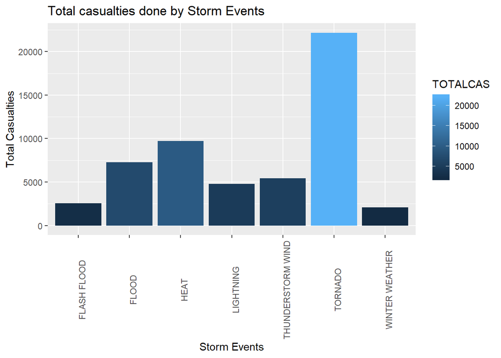

```r
library(ggplot2)

TOTALCASUALTIES %>% subset(CUMULATIVE <= 0.81) %>% ggplot(aes(x = EVENT, y = TOTALCAS )) +
  geom_bar(stat = "identity", aes(fill = TOTALCAS)) +
  ggtitle("Total casualties done by Storm Events") +
  xlab("Storm Events") +
  ylab("Total Casualties") +
  theme(axis.text.x = element_text(angle = 90))
```

Again, these are the events which cause the most casualties on their wake. Tornadoes are by far the most dangerous, with more than 20000 casualties.

### Q2. Which types of events have the greatest economic consequences.

Replicating the analysis done on the previous question, we create the TOTALECONOMICIMPACT dataframe

```r
TOTALECONOMICIMPACT <- StormDataProcessed %>% group_by(EVENT) %>% summarize(TOTALECONOMIC = sum(TOTALDMGVALUE, na.rm = TRUE))

head(TOTALECONOMICIMPACT)
```

```
## # A tibble: 6 x 2
##   EVENT                 TOTALECONOMIC
##   <chr>                         <dbl>
## 1 ASTRONOMICAL LOW TIDE        320000
## 2 AVALANCHE                   3711800
## 3 BLIZZARD                  532718950
## 4 COASTAL FLOOD             391155560
## 5 COLD/WIND CHILL            33286500
## 6 DEBRIS FLOW               346645100
```

```r
TOTALECONOMICIMPACT <- TOTALECONOMICIMPACT[order(TOTALECONOMICIMPACT$TOTALECONOMIC, decreasing = TRUE), ]

print(TOTALECONOMICIMPACT)
```

```
## # A tibble: 46 x 2
##    EVENT               TOTALECONOMIC
##    <chr>                       <dbl>
##  1 FLOOD                149158954700
##  2 HURRICANE (TYPHOON)   87068996810
##  3 STORM SURGE/TIDE      47845004000
##  4 TORNADO               24900377720
##  5 HAIL                  17201087620
##  6 FLASH FLOOD           16558172610
##  7 DROUGHT               14415414600
##  8 THUNDERSTORM WIND      8821431730
##  9 TROPICAL STORM         8320186550
## 10 WILDFIRE               8162804630
## # ... with 36 more rows
```

And then the Pareto’s Principle Analysis

```r
TotalSumEconomic <- sum(TOTALECONOMICIMPACT$TOTALECONOMIC, na.rm = TRUE)

TOTALECONOMICIMPACT$PERCENTAGE <- round(x = TOTALECONOMICIMPACT$TOTALECONOMIC/TotalSumEconomic, digits = 3)

TOTALECONOMICIMPACT$CUMULATIVE <- 0

i <- 0

for (i in 1:nrow(TOTALECONOMICIMPACT)){
  if (i == 1){
    TOTALECONOMICIMPACT[i, 4] <- TOTALECONOMICIMPACT[i, 3]
  }
  else {
    TOTALECONOMICIMPACT[i, 4] <- TOTALECONOMICIMPACT[i, 3] + TOTALECONOMICIMPACT[i-1, 4]
  }
}

print(TOTALECONOMICIMPACT)
```

```
## # A tibble: 46 x 4
##    EVENT               TOTALECONOMIC PERCENTAGE CUMULATIVE
##    <chr>                       <dbl>      <dbl>      <dbl>
##  1 FLOOD                149158954700      0.371      0.371
##  2 HURRICANE (TYPHOON)   87068996810      0.217      0.588
##  3 STORM SURGE/TIDE      47845004000      0.119      0.707
##  4 TORNADO               24900377720      0.062      0.769
##  5 HAIL                  17201087620      0.043      0.812
##  6 FLASH FLOOD           16558172610      0.041      0.853
##  7 DROUGHT               14415414600      0.036      0.889
##  8 THUNDERSTORM WIND      8821431730      0.022      0.911
##  9 TROPICAL STORM         8320186550      0.021      0.932
## 10 WILDFIRE               8162804630      0.02       0.952
## # ... with 36 more rows
```

And it we can see, only 5 of 46 storm events are responsible for 81% of the economical damage in the U.S.

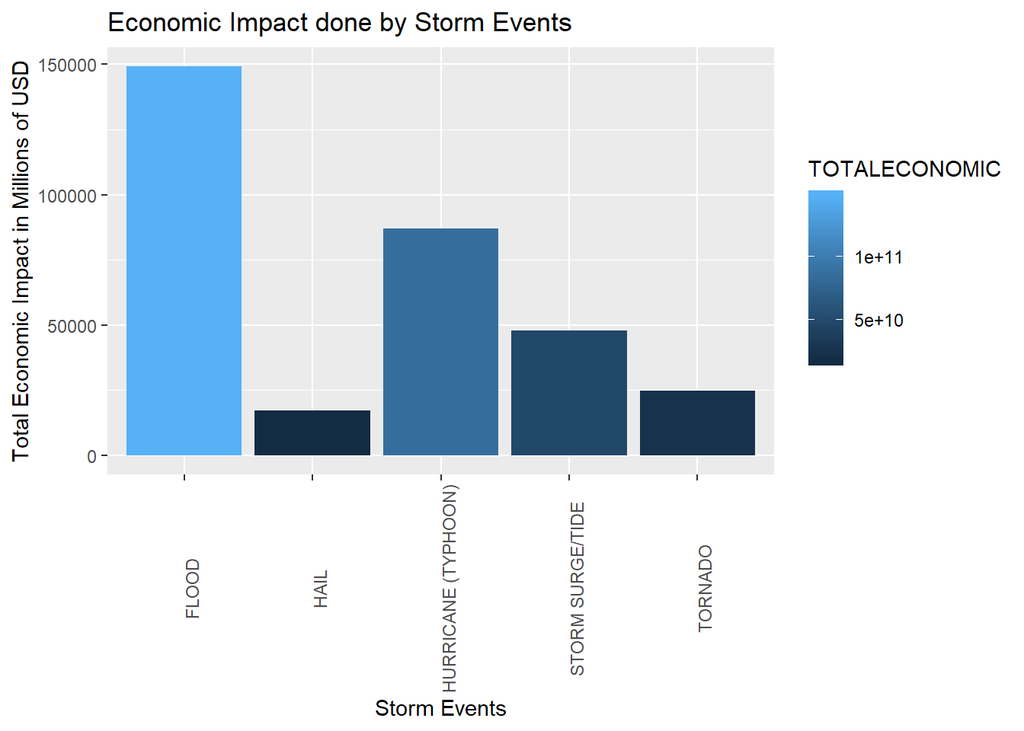

```r
TOTALECONOMICIMPACT %>% subset(CUMULATIVE <= 0.812) %>% ggplot(aes(x = EVENT, y = TOTALECONOMIC/1000000)) +
  geom_bar(stat = "identity", aes(fill = TOTALECONOMIC)) +
  ggtitle("Economic Impact done by Storm Events") +
  xlab("Storm Events")+
  ylab("Total Economic Impact in Millions of USD") +
  theme(axis.text.x = element_text(angle = 90))
```

Finally, it is clear that Floods have the most important economic impacts, follow by Hurricanes.